# Ok Cupid research

## Project description

**Team members**: Пясковська Анна, Шопʼяк Соломія, Ганноченко Дарʼя, Швець Тетяна

**Data set:** [OkCupid Profiles](https://www.kaggle.com/datasets/andrewmvd/okcupid-profiles/data)

**Variables available for analysis**:

- Categorical: relationship status, gender, orientation, body type, diet(vegetarian, vegan, mostly anything), drinks, education, ethnicity(asian, hispanic, latin), job(artistic, computer, banking, sales), location, offspring(does/doesn’t have kids, does/doesn’t want kids), pets, religion, sign(astrological sign), smoking.
- Numerical: age, income, height.

**Goal of the Project**: The goal of this project is to analyze the OkCupid Profiles data set to explore tendencies and relationships in user behavior on the dating app. Specifically, we aim to test four hypotheses about fitness, income and age variation among users. These insights will help understand people in dating apps what to expect from people with different characteristics.

```r
library(ggplot2)
library(dplyr)
library(EnvStats)
library(tidyr)
library(stringr)

data <- read.csv("okcupid_profiles 4.csv")
```

## 1. Willingness of Offspring Comparison

```r
teo_data <- data %>%
  mutate(
    religion_category = case_when(
      grepl("agnosticism|atheism|not too serious", religion, ignore.case = TRUE) ~ "non-religious",
      grepl("christianity|judaism|islam|serious", religion, ignore.case = TRUE) ~ "religious",
      TRUE ~ NA_character_
    )
  )

filtered_data <- teo_data %>%
  filter(
    offspring %in% c(
      "doesn't have kids, but wants them",
      "has a kid, and wants more",
      "doesn't want kids",
      "doesn't have kids, and doesn't want any"
    )
  )

summary <- filtered_data %>%
  mutate(
    wants_kids = offspring %in% c("doesn't have kids, but wants them", "has a kid, and wants more")
  ) %>%
  group_by(religion_category) %>%
  summarize(
    total_count = n(),
    wants_kids_count = sum(wants_kids, na.rm = TRUE),
    wants_kids_percentage = (wants_kids_count / total_count) * 100
  )


summary
```

| religion_category | total_count | wants_kids_count | wants_kids_percentage |
| --- | --- | --- | --- |
| non-religious | 3847 | 1499 | 38.96543 |
| religious | 1191 | 738 | 61.96474 |
| NA | 2657 | 1399 | 52.65337 |

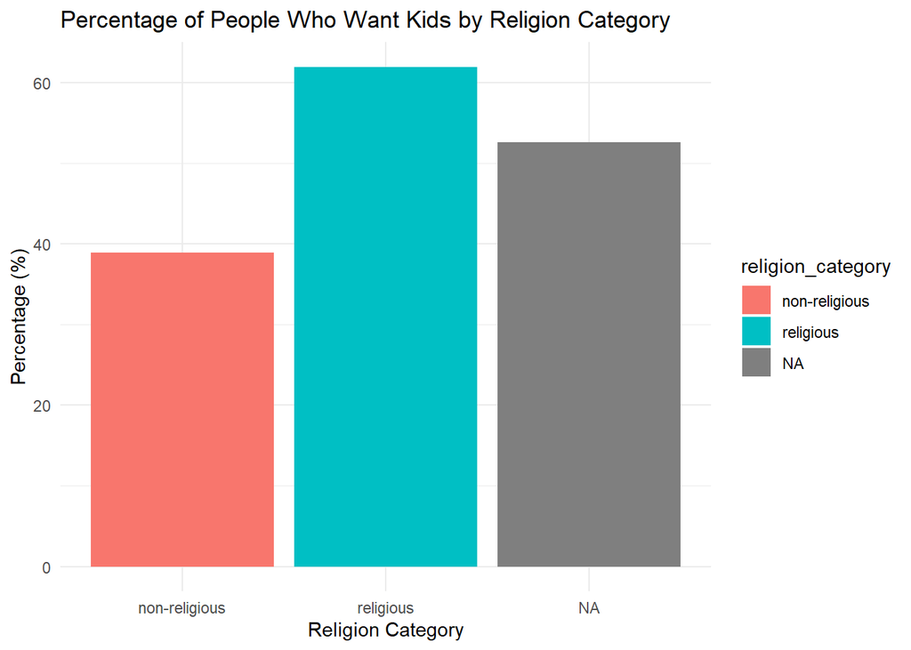

```r
ggplot(summary, aes(x = religion_category, y = wants_kids_percentage, fill = religion_category)) +
  geom_bar(stat = "identity") +
  labs(
    title = "Percentage of People Who Want Kids by Religion Category",
    x = "Religion Category",
    y = "Percentage (%)"
  ) +
  theme_minimal()
```

### Test Willingness of Offspring

- $H_0$: The proportion of people willing to have kids is the same for religious and non-religious users;
- $H_1$: Religious users are willing to have kids more than non-religious.

In this case, we are analyzing two categorical variables — **religion** and **offspring**. To determine whether there is a relationship between these variables, we use the Chi-squared test, which is designed for determining relationship in categorical data.

```r
cleaned_data <- filtered_data %>%
  filter(!is.na(religion_category))

contingency_table <- cleaned_data %>%
  mutate(
    wants_kids = offspring %in% c("doesn't have kids, but wants them", "has a kid, and wants more")
  ) %>%
  group_by(religion_category, wants_kids) %>%
  summarize(count = n(), .groups = "drop") %>%
  pivot_wider(names_from = wants_kids, values_from = count, values_fill = 0)

contingency_table <- as.data.frame(contingency_table)
rownames(contingency_table) <- contingency_table$religion_category
contingency_table <- as.matrix(contingency_table[, -1])

colnames(contingency_table) <- c("Doesn't Want Kids", "Wants Kids")

cat("Contingency Table:\n")
```

```
## Contingency Table:
```

```r
contingency_table
```

```
##               Doesn't Want Kids Wants Kids
## non-religious              2348       1499
## religious                   453        738
```

```r
chi_sq_test <- chisq.test(contingency_table)

cat("\nChi-squared Test Results:\n")
```

```
##
## Chi-squared Test Results:
```

```r
chi_sq_test
```

```
##
##  Pearson's Chi-squared test with Yates' continuity correction
##
## data:  contingency_table
## X-squared = 193.94, df = 1, p-value < 2.2e-16
```

The p-value from the test is $2.2×10^{-16}$, which is significantly less than the significance level 0.05. Thus, we reject the null hypothesis. This means that the proportion of people willing to have kids is not the same for religious and non-religious users.

Even from the visual representation, we observe a clear difference: only **38.9%** of non-religious people want to have children, compared to **61.9%** of religious people. This supports conclusion that there is a significant association between religion and willingness to have kids.

## 2. Vegetarians tend to be more fit than non-vegetarians

After looking at our data we’ve noticed some relation between the diet of an individual and their body type, specifically that vegetarians tend to be more fit than non-vegetarians.

### Data preparation and visualization

```r
unique(data$body_type)
```

```
##  [1] "a little extra" "average"        "thin"           "athletic"
##  [5] "fit"            ""               "skinny"         "curvy"
##  [9] "full figured"   "jacked"         "rather not say" "used up"
## [13] "overweight"
```

```r
unique(data$diet)
```

```
##  [1] "strictly anything"   "mostly other"        "anything"
##  [4] "vegetarian"          ""                    "mostly anything"
##  [7] "mostly vegetarian"   "strictly vegan"      "strictly vegetarian"
## [10] "mostly vegan"        "strictly other"      "mostly halal"
## [13] "other"               "vegan"               "mostly kosher"
## [16] "strictly halal"      "halal"               "strictly kosher"
## [19] "kosher"
```

For simplicity we assign each category of body_type a numeric value, ranging from “overweight” being 1 to “fit” being 5.

```r
fitness_levels <- c("fit" = 5, "athletic" = 4, "thin" = 3, "average" = 2,
                    "a little extra" = 1, "curvy" = 1, "full figured" = 1,
                    "overweight" = 1, "skinny" = 3, "jacked" = 4)
```

As for diet, we consider all vegan related categories as “Vegetarian” and all “ordinary diet” categories as “Non-Vegetarian”.

```r
data_2 <- data %>%
  mutate(
    body_type_numeric = fitness_levels[body_type],
    diet_category = case_when(
      diet %in% c("vegan", "strictly vegetarian", "mostly vegetarian",
                  "strictly vegan", "mostly vegan", "vegetarian") ~ "Vegetarian",
      diet %in% c("strictly anything", "anything", "mostly anything") ~ "Non-Vegetarian",
      TRUE ~ NA_character_
    )
  ) %>%
  filter(!is.na(body_type_numeric), !is.na(diet_category))

vegetarians <- filter(data_2, diet_category == "Vegetarian")$body_type_numeric
non_vegetarians <- filter(data_2, diet_category == "Non-Vegetarian")$body_type_numeric
```

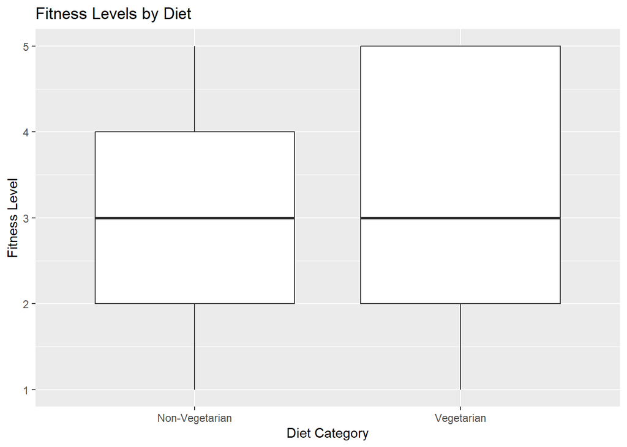

```r
ggplot(data_2, aes(x = diet_category, y = body_type_numeric)) +
  geom_boxplot() +
  labs(title = "Fitness Levels by Diet", x = "Diet Category", y = "Fitness Level")
```

From the box plot we see that both vegetarians and non-vegetarians body type distributions are centered around the same value of approximately 3, however vegetarians body type distribution seems to be more right skewed. We also can observe that on higher values of fitness vegetarians has higher representation than non-vegetarians.

### Constructing a test

To test whether vegetarians tend to be more fit than non-vegetarians, we suggest to consider the following hypotheses: $H_0: \mu_{veg} = \mu_{ord}$ vs $H_1: \mu_{veg} \ge \mu_{ord}$.

Or in other words:

- $H_0$: The average level of fitness is the same for vegetarians and non-vegetarians;
- $H_1$: The average level of fitness is higher for vegetarians than non-vegetarians.

Since the variance is unknown we can use a t-test with the following t-statistics:

$$t(x,y) :=
\sqrt{\frac{mn}{m+n}}\sqrt{\frac{n+m-2}{S_{xx}+S_{yy}}}(\bar{X}-\bar{Y})
\sim \mathscr{T}_{n+m-2}$$

Let $X$ denote level of fitness of a vegetarian and $Y$ - of a non-vegetarian. Then here we consider the difference of sample means $\bar{X} - \bar{Y}$ and normalize it by subtracting the mean (which is 0) and dividing by standard deviation, but since variance is unknown we use an estimator of sigma: $\frac{S_{xx}+S_{yy}}{n+m-2}$.

To be able to run a test two main assumptions has to be held:

- $X$ and $Y$ are normally distributed
- $X$ and $Y$ have the same variance

**Normality**: while we cannot state that $X$ and $Y$ are normally distributed (they are probably not), we can look at our test statistics and see that it is constructed via sample means. By CLT on large sample size sample mean is approximately normally distributed, so we can say that normality holds.

**Homogeneity of variances**: to figure whether this assumption holds we suggest running an f-test: $H_0: \sigma^2_x = \sigma^2_y$ vs $H_1: \sigma^2_x \ne \sigma^2_y$.

Using estimators for variances $\hat{\sigma^2_x} := \frac{S_{xx}}{n-1}$, $\hat{\sigma^2_y} := \frac{S_{yy}}{m-1}$ and considering the ratio of those two we can construct a test statistics:

$$f(x,y) :=
\frac{S_{xx}(m-1)}{(n-1)S_{yy}} \sim \mathscr{F}_{n-1, m-1}$$

```r
var.test(vegetarians, non_vegetarians)
```

```
##
##  F test to compare two variances
##
## data:  vegetarians and non_vegetarians
## F = 1.0213, num df = 5253, denom df = 26546, p-value = 0.3208
## alternative hypothesis: true ratio of variances is not equal to 1
## 95 percent confidence interval:
##  0.9796954 1.0652477
## sample estimates:
## ratio of variances
##           1.021273
```

We’ve obtained ratio of variances very close to 1 and a p-value greater than 0.05, which means that we fail to reject the null hypothesis and that variances of two samples are approximately equal. So homogeneity holds too.

Now we can run a t-test described earlier.

### Running a test

```r
t.test(vegetarians, non_vegetarians, alternative = "greater", var.equal = TRUE)
```

```
##
##  Two Sample t-test
##
## data:  vegetarians and non_vegetarians
## t = 2.4705, df = 31799, p-value = 0.006749
## alternative hypothesis: true difference in means is greater than 0
## 95 percent confidence interval:
##  0.01767814        Inf
## sample estimates:
## mean of x mean of y
##  3.192615  3.139714
```

### Conclusion

We see that p-value for our t-test is less than 0.05, meaning that we reject $H_0$ (the average level of fitness is the same for vegetarians and non-vegetarians) and, thus, make a conclusion that **level of fitness is on average higher for vegetarians than non-vegetarians**.

## 3. Linear Regression

```r
cleaned_data <- subset(data, income > 0)

religions <- c("agnosticism", "atheism", "buddhism", "christianity", "islam", "hinduism", "judaism", "other")
religion_df <- data.frame(matrix(ncol = length(religions), nrow = nrow(cleaned_data)))
colnames(religion_df) <- religions

for (religion in religions) {
  column_name <- gsub(" ", "_", religion)

  if (religion == "christianity") {
    religion_df[[column_name]] <- ifelse(grepl("catholicism", cleaned_data$religion, ignore.case = TRUE) |
                                         grepl("christianity", cleaned_data$religion, ignore.case = TRUE), 1, 0)
  } else if (religion == "other") {
    religion_df[[column_name]] <- ifelse(is.na(cleaned_data$religion) | cleaned_data$religion == "", 1, 0)
  } else {
    religion_df[[column_name]] <- ifelse(grepl(religion, cleaned_data$religion, ignore.case = TRUE), 1, 0)
  }
}

religion_df <- religion_df %>% select(everything())
write.csv(religion_df, "output_religion_strong_1_0.csv", row.names = FALSE)
```

```r
cleaned_data <- subset(data, income > 0)
cleaned_data <- cleaned_data %>%
  mutate(
    job_artistic = ifelse(job == "artistic / musical / writer", 1, 0),
    job_computer = ifelse(job == "computer / hardware / software", 1, 0),
    job_medicine = ifelse(job == "medicine / health", 1, 0),
    job_sales = ifelse(job == "sales / marketing / biz dev", 1, 0),
    job_science = ifelse(job == "science / tech / engineering", 1, 0)
  )

cleaned_data <- cleaned_data %>%
  mutate(
    location_alameda = ifelse(location == "alameda, california", 1, 0),
    location_berkeley = ifelse(location == "berkeley, california", 1, 0),
    location_oakland = ifelse(location == "oakland, california", 1, 0),
    location_palo_alto = ifelse(location == "palo alto, california", 1, 0),
    location_san_francisco = ifelse(location == "san francisco, california", 1, 0)
  )

cleaned_data <- cleaned_data %>%
  mutate(
    languages_count = str_split(speaks, ",") %>%
      lapply(function(x) x[!str_detect(x, "c\\+\\+|other")]) %>%
      sapply(length)
  )

numeric_data <- cleaned_data %>%
  select(
    income, job_artistic, job_computer, job_medicine, job_sales, job_science,
    location_alameda, location_berkeley, location_oakland, location_palo_alto, location_san_francisco,
    languages_count
  )

numeric_data <- cbind(numeric_data, religion_df)

write.csv(numeric_data, "numerical_data.csv", row.names = FALSE)
```

## Multiple Linear Regression Analysis

We will model the relationship between one dependent variable (income) and independent variables (job, location). The goal is to understand how changes in the independent variables are associated with changes in the dependent variable.

1. The multiple linear regression model can be represented as:
   $$Y = \beta_0 + \beta_1X_1 + \beta_2X_2 + \dots + \beta_kX_k + \epsilon$$
   - $Y$: Dependent variable (income, in our case).
   - $X_1, X_2, \dots, X_k$: Independent variables (predictors: job, location).
   - $\beta_0$: Intercept, representing the expected value of $Y$ when all $X$’s are 0.
   - $\beta_1, \beta_2, \dots, \beta_k$: Slopes, indicating the change in $Y$ for a one-unit increase in $X$, holding all other variables constant.
   - $\epsilon$: Error term, accounting for variability in $Y$ not explained by the predictors.
   - P-value ($Pr(>|t|)$): Indicates whether a coefficient is statistically significant. A small $p$-value (typically < 0.05) suggests the predictor has a significant effect on $Y$.
   - Standard Error: Measures the accuracy of the coefficient estimates.
   - t-value: The test statistic for evaluating the null hypothesis that $\beta_i = 0$.
   - R-squared ($R^2$): Proportion of the variance in $Y$ explained by the predictors. Higher values indicate better model fit.
   - Adjusted $R^2$: Adjusted for the number of predictors; penalizes for adding predictors that do not improve the model significantly.
   - F-statistic: Tests whether the overall regression model is significant.

### **Dependent Variable**:

- **income**: Numeric variable representing the income of individuals.

### **Independent Variables (Predictors)**:

#### **Job Types** (Binary Variables):

- **job_artistic**:
  - `1`: Individual works in an artistic profession.
  - `0`: Individual does not work in an artistic profession.
- **job_medicine**:
  - `1`: Individual works in medicine.
  - `0`: Individual does not work in medicine.
- **job_sales**:
  - `1`: Individual works in marketing.
  - `0`: Individual does not work marketing.
- **job_computer**:
  - `1`: Individual works in a computer-related profession.
  - `0`: Individual does not work in a computer-related profession.
- **job_science**:
  - `1`: Individual is a scientist.
  - `0`: Individual is not a scientist.

#### **Location** (Binary Variables):

- **location_san_francisco:**
  - `1`: Individual lives in San_francisco.
  - `0`: Individual does not live in San_francisco.
- **location_palo_alto:**
  - `1`: Individual lives in Palo alto.
  - `0`: Individual does not live in Palo alto.
- **location_oakland:**
  - `1`: Individual lives in Oakland.
  - `0`: Individual does not live in Oakland.
- **location_berkeley**:
  - `1`: Individual lives in Berkeley.
  - `0`: Individual does not live in Berkeley.
- **location_alameda:**
  - `1`: Individual lives in Alameda.
  - `0`: Individual does not live in Alameda.

#### **Religion** (Binary Variables):

- **agnosticism**:
  - `1`: Individual professes agnosticism.
  - `0`: Individual doesn’t professes agnosticism.
- **atheism**:
  - `1`: Individual professes atheism.
  - `0`: Individual doesn’t professes atheism.
- **buddhism**:
  - `1`: Individual professes buddhism.
  - `0`: Individual doesn’t professes buddhism.
- **christianity**:
  - `1`: Individual professes christianity.
  - `0`: Individual doesn’t professes christianity.
- **islam**:
  - `1`: Individual professes islam.
  - `0`: Individual doesn’t professes islam.
- **hinduism**:
  - `1`: Individual professes hinduism.
  - `0`: Individual doesn’t professes hinduism.
- **judaism**:
  - `1`: Individual professes judaism.
  - `0`: Individual doesn’t professes judaism.

### **Important Notes**:

1. In linear regression, when we have categorical variables with multiple levels, one category is always excluded to avoid a problem known as multicollinearity. Because when all categories are included, the variables become linearly dependent (they sum up to 1). So, variables like `job_education` and `location_emeryville` not included in the regression model and are as the baseline or reference category.
2. Individual can be only in one category.

```r
model <- lm(income ~ . - other , data = numeric_data)

model_summary <- summary(model)
model_summary
```

```
##
## Call:
## lm(formula = income ~ . - other, data = numeric_data)
##
## Residuals:
##     Min      1Q  Median      3Q     Max
## -172944  -74804  -46454  -10717  944028
##
## Coefficients:
##                        Estimate Std. Error t value Pr(>|t|)
## (Intercept)               65735       5267  12.480  < 2e-16 ***
## job_artistic              19920       6692   2.977  0.00292 **
## job_computer               1964       6436   0.305  0.76030
## job_medicine               6459       8219   0.786  0.43197
## job_sales                 -8275       7219  -1.146  0.25172
## job_science                2662       6892   0.386  0.69932
## location_alameda         -12174      13676  -0.890  0.37337
## location_berkeley          6704       8129   0.825  0.40957
## location_oakland          17115       6107   2.802  0.00508 **
## location_palo_alto        15690      14660   1.070  0.28455
## location_san_francisco    34617       4392   7.881 3.54e-15 ***
## languages_count           14535       1845   7.880 3.58e-15 ***
## agnosticism              -10806       5497  -1.966  0.04934 *
## atheism                   -4169       5812  -0.717  0.47322
## buddhism                   2026       9976   0.203  0.83907
## christianity             -24297       5065  -4.797 1.63e-06 ***
## islam                    -40520      33467  -1.211  0.22602
## hinduism                   3358      21206   0.158  0.87417
## judaism                   -9814       9815  -1.000  0.31738
## ---
## Signif. codes:  0 '***' 0.001 '**' 0.01 '*' 0.05 '.' 0.1 ' ' 1
##
## Residual standard error: 199800 on 11485 degrees of freedom
## Multiple R-squared:  0.01755,    Adjusted R-squared:  0.01601
## F-statistic:  11.4 on 18 and 11485 DF,  p-value: < 2.2e-16
```

```r
without_hinduism <- income ~ . - other - hinduism

model_updated <- lm(without_hinduism, data = numeric_data)

summary(model_updated)
```

```
##
## Call:
## lm(formula = without_hinduism, data = numeric_data)
##
## Residuals:
##     Min      1Q  Median      3Q     Max
## -173045  -74867  -46145  -10701  944041
##
## Coefficients:
##                        Estimate Std. Error t value Pr(>|t|)
## (Intercept)               65777       5260  12.505  < 2e-16 ***
## job_artistic              19923       6692   2.977  0.00291 **
## job_computer               2013       6428   0.313  0.75421
## job_medicine               6476       8218   0.788  0.43073
## job_sales                 -8260       7218  -1.144  0.25252
## job_science                2672       6891   0.388  0.69820
## location_alameda         -12200      13674  -0.892  0.37232
## location_berkeley          6701       8129   0.824  0.40978
## location_oakland          17105       6106   2.801  0.00510 **
## location_palo_alto        15689      14660   1.070  0.28454
## location_san_francisco    34620       4392   7.882 3.50e-15 ***
## languages_count           14545       1843   7.890 3.29e-15 ***
## agnosticism              -10878       5478  -1.986  0.04710 *
## atheism                   -4242       5794  -0.732  0.46416
## buddhism                   1955       9966   0.196  0.84448
## christianity             -24364       5047  -4.827 1.40e-06 ***
## islam                    -40595      33462  -1.213  0.22509
## judaism                   -9886       9804  -1.008  0.31332
## ---
## Signif. codes:  0 '***' 0.001 '**' 0.01 '*' 0.05 '.' 0.1 ' ' 1
##
## Residual standard error: 199800 on 11486 degrees of freedom
## Multiple R-squared:  0.01755,    Adjusted R-squared:  0.01609
## F-statistic: 12.07 on 17 and 11486 DF,  p-value: < 2.2e-16
```

```r
without_buddhism <- income ~ . - other - hinduism - buddhism

model_updated <- lm(without_buddhism, data = numeric_data)

summary(model_updated)
```

```
##
## Call:
## lm(formula = without_buddhism, data = numeric_data)
##
## Residuals:
##     Min      1Q  Median      3Q     Max
## -173332  -75042  -46250  -10670  944062
##
## Coefficients:
##                        Estimate Std. Error t value Pr(>|t|)
## (Intercept)               65899       5223  12.616  < 2e-16 ***
## job_artistic              19954       6689   2.983  0.00286 **
## job_computer               2016       6428   0.314  0.75387
## job_medicine               6476       8218   0.788  0.43074
## job_sales                 -8283       7217  -1.148  0.25115
## job_science                2664       6891   0.387  0.69903
## location_alameda         -12175      13673  -0.890  0.37325
## location_berkeley          6742       8126   0.830  0.40671
## location_oakland          17113       6106   2.803  0.00508 **
## location_palo_alto        15656      14658   1.068  0.28551
## location_san_francisco    34621       4392   7.883 3.48e-15 ***
## languages_count           14572       1838   7.926 2.46e-15 ***
## agnosticism              -11055       5403  -2.046  0.04077 *
## atheism                   -4421       5721  -0.773  0.43963
## christianity             -24533       4973  -4.933 8.19e-07 ***
## islam                    -40788      33447  -1.219  0.22268
## judaism                  -10066       9760  -1.031  0.30244
## ---
## Signif. codes:  0 '***' 0.001 '**' 0.01 '*' 0.05 '.' 0.1 ' ' 1
##
## Residual standard error: 199800 on 11487 degrees of freedom
## Multiple R-squared:  0.01754,    Adjusted R-squared:  0.01617
## F-statistic: 12.82 on 16 and 11487 DF,  p-value: < 2.2e-16
```

```r
without_job_computer <- income ~ . - other - hinduism - buddhism - job_computer

model_updated <- lm(without_job_computer, data = numeric_data)

summary(model_updated)
```

```
##
## Call:
## lm(formula = without_job_computer, data = numeric_data)
##
## Residuals:
##     Min      1Q  Median      3Q     Max
## -173363  -75295  -45839  -10804  943871
##
## Coefficients:
##                        Estimate Std. Error t value Pr(>|t|)
## (Intercept)               66135       5168  12.796  < 2e-16 ***
## job_artistic              19652       6620   2.969  0.00300 **
## job_medicine               6199       8170   0.759  0.44804
## job_sales                 -8569       7159  -1.197  0.23135
## job_science                2342       6814   0.344  0.73102
## location_alameda         -12168      13672  -0.890  0.37349
## location_berkeley          6664       8122   0.821  0.41189
## location_oakland          17045       6102   2.793  0.00523 **
## location_palo_alto        15855      14644   1.083  0.27895
## location_san_francisco    34675       4388   7.902 3.01e-15 ***
## languages_count           14580       1838   7.932 2.35e-15 ***
## agnosticism              -10958       5394  -2.032  0.04221 *
## atheism                   -4264       5699  -0.748  0.45434
## christianity             -24587       4970  -4.947 7.63e-07 ***
## islam                    -40704      33444  -1.217  0.22360
## judaism                  -10018       9759  -1.027  0.30463
## ---
## Signif. codes:  0 '***' 0.001 '**' 0.01 '*' 0.05 '.' 0.1 ' ' 1
##
## Residual standard error: 199800 on 11488 degrees of freedom
## Multiple R-squared:  0.01753,    Adjusted R-squared:  0.01625
## F-statistic: 13.67 on 15 and 11488 DF,  p-value: < 2.2e-16
```

```r
without_job_science <- income ~ . - other - hinduism - buddhism - job_computer - job_science

model_updated <- lm(without_job_science, data = numeric_data)

summary(model_updated)
```

```
##
## Call:
## lm(formula = without_job_science, data = numeric_data)
##
## Residuals:
##     Min      1Q  Median      3Q     Max
## -173415  -75533  -45682  -10933  943708
##
## Coefficients:
##                        Estimate Std. Error t value Pr(>|t|)
## (Intercept)               66332       5136  12.914  < 2e-16 ***
## job_artistic              19389       6575   2.949  0.00319 **
## job_medicine               5960       8140   0.732  0.46406
## job_sales                 -8811       7124  -1.237  0.21616
## location_alameda         -12226      13671  -0.894  0.37118
## location_berkeley          6698       8121   0.825  0.40951
## location_oakland          17004       6101   2.787  0.00533 **
## location_palo_alto        16060      14631   1.098  0.27239
## location_san_francisco    34691       4388   7.906 2.90e-15 ***
## languages_count           14600       1837   7.948 2.07e-15 ***
## agnosticism              -10899       5391  -2.022  0.04322 *
## atheism                   -4153       5689  -0.730  0.46542
## christianity             -24641       4967  -4.961 7.11e-07 ***
## islam                    -40725      33443  -1.218  0.22335
## judaism                  -10028       9758  -1.028  0.30413
## ---
## Signif. codes:  0 '***' 0.001 '**' 0.01 '*' 0.05 '.' 0.1 ' ' 1
##
## Residual standard error: 199800 on 11489 degrees of freedom
## Multiple R-squared:  0.01752,    Adjusted R-squared:  0.01633
## F-statistic: 14.64 on 14 and 11489 DF,  p-value: < 2.2e-16
```

```r
without_atheism <- income ~ . - other - hinduism - buddhism - job_computer - job_science - atheism

model_updated <- lm(without_atheism, data = numeric_data)

summary(model_updated)
```

```
##
## Call:
## lm(formula = without_atheism, data = numeric_data)
##
## Residuals:
##     Min      1Q  Median      3Q     Max
## -172244  -74565  -45974  -10924  943658
##
## Coefficients:
##                        Estimate Std. Error t value Pr(>|t|)
## (Intercept)               65423       4983  13.130  < 2e-16 ***
## job_artistic              19438       6574   2.957  0.00312 **
## job_medicine               6238       8131   0.767  0.44299
## job_sales                 -8583       7117  -1.206  0.22783
## location_alameda         -12207      13670  -0.893  0.37189
## location_berkeley          6442       8113   0.794  0.42718
## location_oakland          16862       6097   2.765  0.00569 **
## location_palo_alto        15921      14630   1.088  0.27649
## location_san_francisco    34582       4385   7.886 3.41e-15 ***
## languages_count           14560       1836   7.930 2.40e-15 ***
## agnosticism               -9854       5197  -1.896  0.05798 .
## christianity             -23641       4774  -4.952 7.46e-07 ***
## islam                    -39649      33410  -1.187  0.23535
## judaism                   -8987       9654  -0.931  0.35190
## ---
## Signif. codes:  0 '***' 0.001 '**' 0.01 '*' 0.05 '.' 0.1 ' ' 1
##
## Residual standard error: 199800 on 11490 degrees of freedom
## Multiple R-squared:  0.01748,    Adjusted R-squared:  0.01637
## F-statistic: 15.72 on 13 and 11490 DF,  p-value: < 2.2e-16
```

```r
without_job_medicine <- income ~ . - other - hinduism - buddhism - job_computer - job_science - atheism - job_medicine

model_updated <- lm(without_job_medicine, data = numeric_data)

summary(model_updated)
```

```
##
## Call:
## lm(formula = without_job_medicine, data = numeric_data)
##
## Residuals:
##     Min      1Q  Median      3Q     Max
## -172161  -74976  -45951  -10537  943126
##
## Coefficients:
##                        Estimate Std. Error t value Pr(>|t|)
## (Intercept)               65883       4947  13.319  < 2e-16 ***
## job_artistic              19032       6553   2.904  0.00369 **
## job_sales                 -9015       7094  -1.271  0.20385
## location_alameda         -12025      13668  -0.880  0.37900
## location_berkeley          6399       8113   0.789  0.43029
## location_oakland          16820       6097   2.759  0.00581 **
## location_palo_alto        15759      14628   1.077  0.28136
## location_san_francisco    34555       4385   7.880 3.57e-15 ***
## languages_count           14538       1836   7.919 2.62e-15 ***
## agnosticism               -9884       5197  -1.902  0.05722 .
## christianity             -23547       4773  -4.934 8.18e-07 ***
## islam                    -39820      33408  -1.192  0.23332
## judaism                   -8830       9651  -0.915  0.36027
## ---
## Signif. codes:  0 '***' 0.001 '**' 0.01 '*' 0.05 '.' 0.1 ' ' 1
##
## Residual standard error: 199800 on 11491 degrees of freedom
## Multiple R-squared:  0.01743,    Adjusted R-squared:  0.0164
## F-statistic: 16.98 on 12 and 11491 DF,  p-value: < 2.2e-16
```

```r
without_berkeley <- income ~ . - other - hinduism - buddhism - job_computer - job_science - atheism - job_medicine - location_berkeley

model_updated <- lm(without_berkeley, data = numeric_data)

summary(model_updated)
```

```
##
## Call:
## lm(formula = without_berkeley, data = numeric_data)
##
## Residuals:
##     Min      1Q  Median      3Q     Max
## -172722  -75676  -46148  -11508  942402
##
## Coefficients:
##                        Estimate Std. Error t value Pr(>|t|)
## (Intercept)               66864       4788  13.966  < 2e-16 ***
## job_artistic              19208       6549   2.933  0.00336 **
## job_sales                 -9128       7093  -1.287  0.19815
## location_alameda         -13093      13601  -0.963  0.33572
## location_oakland          15690       5926   2.648  0.00812 **
## location_palo_alto        14640      14558   1.006  0.31465
## location_san_francisco    33427       4146   8.063 8.16e-16 ***
## languages_count           14645       1831   7.999 1.38e-15 ***
## agnosticism               -9890       5197  -1.903  0.05705 .
## christianity             -23910       4750  -5.033 4.89e-07 ***
## islam                    -39793      33408  -1.191  0.23363
## judaism                   -8814       9651  -0.913  0.36112
## ---
## Signif. codes:  0 '***' 0.001 '**' 0.01 '*' 0.05 '.' 0.1 ' ' 1
##
## Residual standard error: 199800 on 11492 degrees of freedom
## Multiple R-squared:  0.01737,    Adjusted R-squared:  0.01643
## F-statistic: 18.47 on 11 and 11492 DF,  p-value: < 2.2e-16
```

```r
without_judaism <- income ~ . - other - hinduism - buddhism - job_computer - job_science - atheism - job_medicine - location_berkeley -judaism

model_updated <- lm(without_judaism, data = numeric_data)

summary(model_updated)
```

```
##
## Call:
## lm(formula = without_judaism, data = numeric_data)
##
## Residuals:
##     Min      1Q  Median      3Q     Max
## -172021  -75610  -45610  -11036  942327
##
## Coefficients:
##                        Estimate Std. Error t value Pr(>|t|)
## (Intercept)               66430       4764  13.944  < 2e-16 ***
## job_artistic              19277       6549   2.944  0.00325 **
## job_sales                 -9215       7092  -1.299  0.19386
## location_alameda         -13075      13600  -0.961  0.33640
## location_oakland          15639       5926   2.639  0.00832 **
## location_palo_alto        14531      14558   0.998  0.31823
## location_san_francisco    33364       4145   8.049 9.15e-16 ***
## languages_count           14590       1830   7.973 1.70e-15 ***
## agnosticism               -9314       5158  -1.806  0.07100 .
## christianity             -23348       4710  -4.957 7.27e-07 ***
## islam                    -39209      33401  -1.174  0.24047
## ---
## Signif. codes:  0 '***' 0.001 '**' 0.01 '*' 0.05 '.' 0.1 ' ' 1
##
## Residual standard error: 199800 on 11493 degrees of freedom
## Multiple R-squared:  0.0173, Adjusted R-squared:  0.01645
## F-statistic: 20.24 on 10 and 11493 DF,  p-value: < 2.2e-16
```

```r
without_alameda <- income ~ . - other - hinduism - buddhism - job_computer - job_science - atheism - job_medicine - location_berkeley -judaism -location_alameda

model_updated <- lm(without_alameda, data = numeric_data)

summary(model_updated)
```

```
##
## Call:
## lm(formula = without_alameda, data = numeric_data)
##
## Residuals:
##     Min      1Q  Median      3Q     Max
## -172079  -74969  -45659  -11029  942970
##
## Coefficients:
##                        Estimate Std. Error t value Pr(>|t|)
## (Intercept)               65710       4705  13.967  < 2e-16 ***
## job_artistic              19223       6548   2.936  0.00334 **
## job_sales                 -9123       7092  -1.286  0.19830
## location_oakland          16281       5888   2.765  0.00570 **
## location_palo_alto        15158      14543   1.042  0.29729
## location_san_francisco    33997       4092   8.308  < 2e-16 ***
## languages_count           14630       1830   7.997 1.40e-15 ***
## agnosticism               -9311       5158  -1.805  0.07110 .
## christianity             -23310       4710  -4.949 7.57e-07 ***
## islam                    -38893      33400  -1.164  0.24426
## ---
## Signif. codes:  0 '***' 0.001 '**' 0.01 '*' 0.05 '.' 0.1 ' ' 1
##
## Residual standard error: 199800 on 11494 degrees of freedom
## Multiple R-squared:  0.01722,    Adjusted R-squared:  0.01645
## F-statistic: 22.38 on 9 and 11494 DF,  p-value: < 2.2e-16
```

```r
without_palo_alto <- income ~ . - other - hinduism - buddhism - job_computer - job_science - atheism - job_medicine - location_berkeley -judaism -location_alameda -location_palo_alto

model_updated <- lm(without_palo_alto, data = numeric_data)

summary(model_updated)
```

```
##
## Call:
## lm(formula = without_palo_alto, data = numeric_data)
##
## Residuals:
##     Min      1Q  Median      3Q     Max
## -172254  -75632  -45632  -10935  942468
##
## Coefficients:
##                        Estimate Std. Error t value Pr(>|t|)
## (Intercept)               66239       4677  14.162  < 2e-16 ***
## job_artistic              19168       6548   2.927  0.00343 **
## job_sales                 -9092       7091  -1.282  0.19985
## location_oakland          15655       5857   2.673  0.00754 **
## location_san_francisco    33365       4047   8.244  < 2e-16 ***
## languages_count           14696       1828   8.038  1.0e-15 ***
## agnosticism               -9331       5158  -1.809  0.07050 .
## christianity             -23404       4709  -4.970  6.8e-07 ***
## islam                    -39256      33398  -1.175  0.23986
## ---
## Signif. codes:  0 '***' 0.001 '**' 0.01 '*' 0.05 '.' 0.1 ' ' 1
##
## Residual standard error: 199800 on 11495 degrees of freedom
## Multiple R-squared:  0.01713,    Adjusted R-squared:  0.01645
## F-statistic: 25.04 on 8 and 11495 DF,  p-value: < 2.2e-16
```

```r
without_islam <- income ~ . - other - hinduism - buddhism - job_computer - job_science - atheism - job_medicine - location_berkeley -judaism -location_alameda -location_palo_alto -islam

model_updated <- lm(without_islam, data = numeric_data)

summary(model_updated)
```

```
##
## Call:
## lm(formula = without_islam, data = numeric_data)
##
## Residuals:
##     Min      1Q  Median      3Q     Max
## -171880  -75381  -45588  -10949  942465
##
## Coefficients:
##                        Estimate Std. Error t value Pr(>|t|)
## (Intercept)               66103       4676  14.137  < 2e-16 ***
## job_artistic              19168       6548   2.927  0.00343 **
## job_sales                 -8977       7091  -1.266  0.20555
## location_oakland          15746       5857   2.688  0.00719 **
## location_san_francisco    33414       4047   8.257  < 2e-16 ***
## languages_count           14639       1828   8.009 1.26e-15 ***
## agnosticism               -9130       5156  -1.771  0.07660 .
## christianity             -23207       4706  -4.931 8.29e-07 ***
## ---
## Signif. codes:  0 '***' 0.001 '**' 0.01 '*' 0.05 '.' 0.1 ' ' 1
##
## Residual standard error: 199800 on 11496 degrees of freedom
## Multiple R-squared:  0.01701,    Adjusted R-squared:  0.01641
## F-statistic: 28.42 on 7 and 11496 DF,  p-value: < 2.2e-16
```

```r
without_job_sales <- income ~ . - other - hinduism - buddhism - job_computer - job_science - atheism - job_medicine - location_berkeley -judaism -location_alameda -location_palo_alto -islam -job_sales

model_updated <- lm(without_job_sales, data = numeric_data)

summary(model_updated)
```

```
##
## Call:
## lm(formula = without_job_sales, data = numeric_data)
##
## Residuals:
##     Min      1Q  Median      3Q     Max
## -171961  -74789  -45898  -10984  943386
##
## Coefficients:
##                        Estimate Std. Error t value Pr(>|t|)
## (Intercept)               65399       4643  14.086  < 2e-16 ***
## job_artistic              19888       6524   3.049  0.00230 **
## location_oakland          15803       5857   2.698  0.00698 **
## location_san_francisco    33199       4043   8.211 2.43e-16 ***
## languages_count           14695       1827   8.042 9.70e-16 ***
## agnosticism               -9110       5156  -1.767  0.07724 .
## christianity             -23480       4701  -4.994 5.99e-07 ***
## ---
## Signif. codes:  0 '***' 0.001 '**' 0.01 '*' 0.05 '.' 0.1 ' ' 1
##
## Residual standard error: 199800 on 11497 degrees of freedom
## Multiple R-squared:  0.01688,    Adjusted R-squared:  0.01636
## F-statistic: 32.89 on 6 and 11497 DF,  p-value: < 2.2e-16
```

```r
without_agnosticism <- income ~ . - other - hinduism - buddhism - job_computer - job_science - atheism - job_medicine - location_berkeley -judaism -location_alameda -location_palo_alto -islam -job_sales -agnosticism

model_updated <- lm(without_agnosticism, data = numeric_data)

summary(model_updated)
```

```
##
## Call:
## lm(formula = without_agnosticism, data = numeric_data)
##
## Residuals:
##     Min      1Q  Median      3Q     Max
## -170005  -74011  -45979  -11336  943310
##
## Coefficients:
##                        Estimate Std. Error t value Pr(>|t|)
## (Intercept)               63615       4532  14.036  < 2e-16 ***
## job_artistic              20099       6523   3.081  0.00207 **
## location_oakland          15754       5857   2.690  0.00717 **
## location_san_francisco    33079       4043   8.181 3.10e-16 ***
## languages_count           14643       1827   8.014 1.22e-15 ***
## christianity             -21567       4576  -4.714 2.46e-06 ***
## ---
## Signif. codes:  0 '***' 0.001 '**' 0.01 '*' 0.05 '.' 0.1 ' ' 1
##
## Residual standard error: 199800 on 11498 degrees of freedom
## Multiple R-squared:  0.01661,    Adjusted R-squared:  0.01618
## F-statistic: 38.84 on 5 and 11498 DF,  p-value: < 2.2e-16
```

### Interpreting the results

Although we are left with model for which all its independent variables are significant (we can see that by both the small p-values for each variable and small p-value for the whole regression model), the overall performance of our model does not seem very good.

First of all, the residual standard error is very high, meaning that our model can’t be considered as a good fit and that it won’t be able to predict accurately enough.

Potential reasons for such results:

- in our data set income column is limited to small uneven range of values (-1, 80000, 20000, 40000, 30000, 50000, 60000, 1000000, 150000, 100000, 500000, 70000, 250000), making it hard for the model to establish the relation between dependent and independent variables
- there are other important factors that influence income, which we do not consider in our regression model or which are not represented in our data set
- the relation between income and independent variables we consider may be non-linear, as we assume
- it is possible that predictors we use are not independent, leading to multicollinearity, which can significantly affect the model’s ability to predict

## 4. Standard deviation of age among users is 9:

### Data visualization

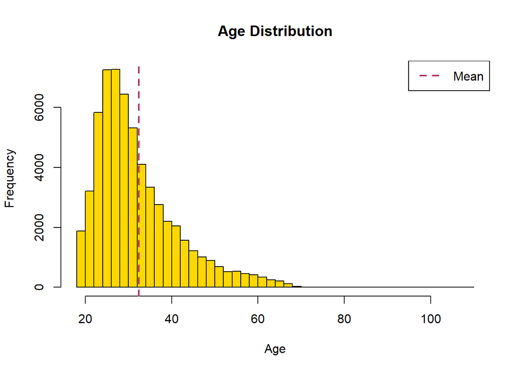

```r
mean_age <- mean(data$age, na.rm = TRUE)
hist(data$age,
     main = "Age Distribution",
     xlab = "Age",
     ylab = "Frequency",
     col = "gold",
     border = "black",
     breaks = 65)

abline(v = mean_age,
       col = "maroon",
       lwd = 2,
       lty = 2)

legend("topright",
       legend = paste("Mean"),
       col = "maroon",
       lty = 2,
       lwd = 2)
```

### Constructing a test

$H_0$ :The population standard deviation of age = 9.

$H_1$ :The population standard deviation of age $\not=$ 9.

if population mean of age is unknown.

To construct our two-sided test we consider the estimate $\bar{X}$ instead of $\mu$ and can get test statistics
$$V(X) = \frac{S_{XX}}{\sigma^2_0}$$
which under $H_0$ has $Chi-squared$ distribution with $n-1$ degrees of freedom.

### Running a test

```r
result <- varTest(data$age, alternative = "two.sided", sigma.squared = 81)

result
```

```
##
## Results of Hypothesis Test
## --------------------------
##
## Null Hypothesis:                 variance = 81
##
## Alternative Hypothesis:          True variance is not equal to 81
##
## Test Name:                       Chi-Squared Test on Variance
##
## Estimated Parameter(s):          variance = 89.35503
##
## Data:                            data$age
##
## Test Statistic:                  Chi-Squared = 66128.24
##
## Test Statistic Parameter:        df = 59945
##
## P-value:                         0
##
## 95% Confidence Interval:         LCL = 88.35201
##                                  UCL = 90.37532
```

### Conclusion

As we can see the p-value is less then 0,05 which means we should reject our $H_0$

In conclusion variance of age in fact **isn’t equal to 81**. But after testing we found its 95% Confidence Interval : $[88,35201 : 90,37532]$